# Reproducible Research: Peer Assessment 1

### Loading and preprocessing the data

```r
data <- read.table(unz("activity.zip", "activity.csv"), header=T, sep=",")
```

### Steps taken each day

1. Total number of steps taken each day

```r
totalDay <- aggregate(data$steps ~ data$date, FUN=sum, na.rm=TRUE)
colnames(totalDay) <- c("date", "step")
```

2. Histogram of the total number of steps taken each day

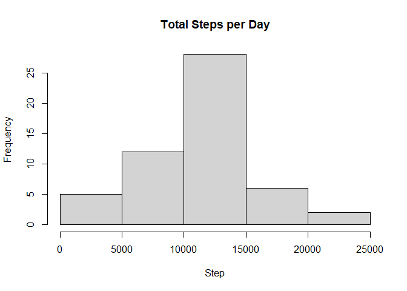

```r
hist(totalDay$step, xlab="Step", main="Total Steps per Day")
```

3. Calculate and report the mean and median of the total number of steps taken per day

Mean of the total number of steps taken per day

```r
mean(totalDay$step)
```

```
## [1] 10766.19
```

Median of the total number of steps taken per day

```r
median(totalDay$step)
```

```
## [1] 10765
```

### Average daily activity pattern

1. Calculating the average number of steps taken by intervals in all days

```r
avgInterval <- aggregate(data$steps ~ data$interval, FUN=mean, na.rm=TRUE)
colnames(avgInterval) <- c("interval", "step")
```

2. Time series plot of the 5-minute interval and the average number of steps

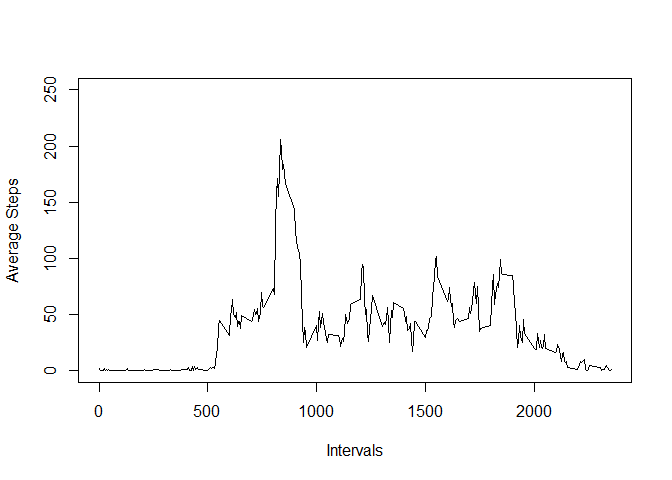

```r
plot(avgInterval$interval, avgInterval$step ,type="l", xlim=c(0, 2355), ylim = c(0, 250), xlab="Intervals", ylab="Average Steps")
```

3. The 5-minute interval that contains the maximum number of steps is:

```r
avgInterval[avgInterval$step == max(avgInterval$step), ]$interval
```

```
## [1] 835
```

### Imputing missing values

1. Total number of missing values in the dataset

```r
sum(is.na(data))
```

```
## [1] 2304
```

2. Strategy for filling in all of the missing values in the data set

I will fill the NA values with the mean of steps, averaged by all days, for that 5-minute interval. The following steps will be taken:

- Check if a record in step varialbe in table data is NA
- If yes, get the 5-minute interval whose step record is missing
- Find the 5-minute interval in the table avgInterval
- When found, get the averaged step record of that 5-minute interval and assign it to the step record in the data table
3. Create a new dataset that is equal to the original dataset but with the missing data filled in The new dataset’s name is data_full

```r
avgInterval$interval <- as.character(avgInterval$interval)
data_full <- data
data_full$interval <- as.character(data_full$interval)
for (i in c(1:length(data_full$steps))) {
        if (is.na(data_full[i, 1])) {
                x <- paste("^", data[i, 3], "$", sep="")
                y <- grepl(x, avgInterval$interval)
                data_full[i, 1] <- avgInterval[y, ]$step
     }
 }
```

4. Histogram of the total number of steps taken each day by the new data set with no NA values

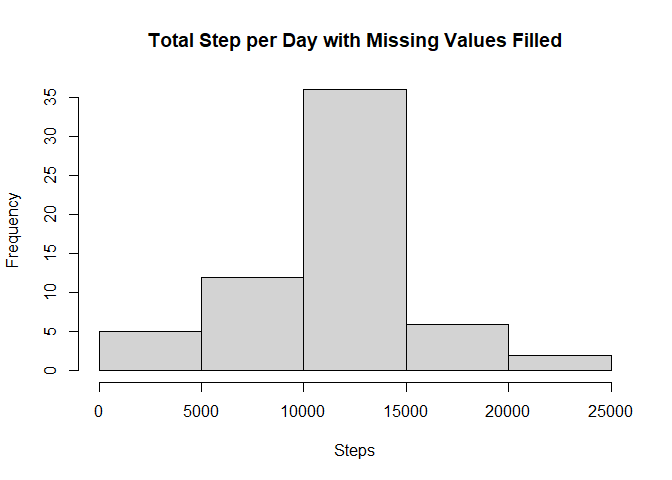

```r
totalDay1 <- aggregate(data_full$steps ~ data_full$date, FUN = sum)
colnames(totalDay1) <- c("data", "step")
hist(totalDay1$step, xlab="Steps", main="Total Step per Day with Missing Values Filled")
```

5. The mean and median total number of steps taken per day in the new data set

The mean

```r
mean(totalDay1$step)
```

```
## [1] 10766.19
```

```r
median(totalDay$step)
```

```
## [1] 10765
```

### Are there differences in activity patterns between weekdays and weekends?

1. New factor in data set with two levels - “weekday” “weekend”

```r
data_full$date <- strptime(data_full$date, "%Y-%m-%d")
weekend <- c("Saturday", "Sunday")
data_full$weekday <- weekdays(data_full$date)
data_full$weekday <- ifelse(data_full$weekday %in% weekend, "weekend", "weekday")
data_full$weekday <- as.factor(data_full$weekday)
```

2. Make a panel plot containing a time series plot of the 5-minute interval (x-axis) and the average number of steps taken

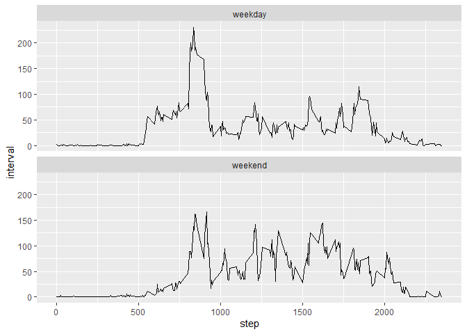

```r
weekdayAvg <- aggregate(data_full$steps, by=list(data_full$weekday, data_full$interval), mean)
colnames(weekdayAvg) <- c("weekday", "interval", "step")
library(ggplot2)
weekdayAvg$interval <- as.numeric(weekdayAvg$interval)
ggplot(data=weekdayAvg, aes(step, interval)) + geom_line(aes(x=interval, y=step)) + facet_wrap(~weekday, ncol=1)
```